# Mantel Tests

Trevor Eakes

May 6, 2016

=============================================================== ###Note: ####Mantel tests are no longer considered an apropriate method for this kind of ecological analysis given that a matrix of jaccard similiarities is not a true disimilarity matrix. A better comparative anaylsis between community, space, and environment will ultimately need to be used based off of most current statistical techniques.

Now that that’s been covered,

First: I set up the data frames needed to create the disimilarity matrices

You will need to have saved in the directory the Adiv.abiotic dataframe, which will be imported here and the ‘test’ dataframe of phytoplankton abundances by station.

===============================================================

```r
Adiv.abiotic <- read.csv('Adiv.abiotic.csv')
phyto <- read.csv('centitest.csv')

#We will need to make a few adjustments to the dataframes to get them ready.

phyto <- phyto[, c(5:length(phyto))] #This get's rid of the station information, and get's rid of the last 5 rows. The last 5 rows don't have any physical data on them so I discard these.

Phyto<- phyto[rowSums(phyto)!=0, ] #Now we get rid of all stations that have no diatoms or dinoflagellates

Phyto[Phyto>0]<- 1 #Data.frame is changed to binary logic, presence absence only instead of abundances

Adiv.abioticD <- Adiv.abiotic[-c(which(rowSums(phyto)==0)),]# Get rid of the same stations which have no diatoms or dinoflagellates


LLD <- cbind(Adiv.abioticD[, c("lon", "lat", "depth..m.")]) #new dataframe with Longitude, Latitude and depth
```

Okay, now that the data.frames needed have been added and eddited into the proper form we can make the distance matrices.

Here we will have the phytoplankton community dissimilarity matrix titled as ‘BioticDist’. This will be a Jaccard dissimilarity index.

And the Environmental dissimilarity matrix which will called ’EnviroDist’and also Euclidean.

```r
require(codep)
require(geosphere)
require(vegan)
require(BBmisc)
LL<- LLD[,-3] #don't know how to deal with depth just yet
PositionDist <- as.matrix(distm(LL)) #without depth
PositionDistd <- as.matrix(dist(LLD)) #with depth. This method is a measure of relative euclidean depth, gives depth over exagerated importance
BioticDist <- as.matrix(vegdist(Phyto, method="jaccard", na.rm=TRUE))

EnvironDist <- as.matrix(dist(normalize(Adiv.abioticD[c("S", "Theta", "Chlorophyll", 'DOC..uM.', 'TDN..uM.', 'SiO2..uM.', 'DON..uM.', 'NO3..uM.', 'NH4.uM.', 'PO4..uM.', 'P.', 'Si.')]))) #All the physical measurements

SimpleEnvironDist <- as.matrix(dist(normalize(Adiv.abioticD[c("S", "Theta", "Chlorophyll")]))) #Just the basics
```

Next the Mantel test will be performed

```r
require(gplots)
mantel.partial(BioticDist, PositionDist, EnvironDist,   method="pearson", permutations=10000) #Partial mantel compares the community simmilarity to the distance matrix with the environment partially out
```

```
##
## Partial Mantel statistic based on Pearson's product-moment correlation
##
## Call:
## mantel.partial(xdis = BioticDist, ydis = PositionDist, zdis = EnvironDist,      method = "pearson", permutations = 10000)
##
## Mantel statistic r: 0.06703
##       Significance: 0.00019998
##
## Upper quantiles of permutations (null model):
##    90%    95%  97.5%    99%
## 0.0211 0.0276 0.0342 0.0427
## Permutation: free
## Number of permutations: 10000
```

```r
mantel.partial(BioticDist, EnvironDist, PositionDist,   method="pearson", permutations=10000) #Partial mantel compares the community simmilarity to the distance matrix with the distance partially out
```

```
##
## Partial Mantel statistic based on Pearson's product-moment correlation
##
## Call:
## mantel.partial(xdis = BioticDist, ydis = EnvironDist, zdis = PositionDist,      method = "pearson", permutations = 10000)
##
## Mantel statistic r: 0.06049
##       Significance: 0.018098
##
## Upper quantiles of permutations (null model):
##    90%    95%  97.5%    99%
## 0.0375 0.0487 0.0569 0.0673
## Permutation: free
## Number of permutations: 10000
```

```r
mantel(BioticDist, PositionDistd,   method="pearson", permutations=10000)#Mantel test between community simmilarity and distance with depth but not with real distances
```

```
##
## Mantel statistic based on Pearson's product-moment correlation
##
## Call:
## mantel(xdis = BioticDist, ydis = PositionDistd, method = "pearson",      permutations = 10000)
##
## Mantel statistic r: 0.01808
##       Significance: 0.20898
##
## Upper quantiles of permutations (null model):
##    90%    95%  97.5%    99%
## 0.0290 0.0374 0.0449 0.0546
## Permutation: free
## Number of permutations: 10000
```

```r
mantel(BioticDist, PositionDist,   method="pearson", permutations=10000)
```

```
##
## Mantel statistic based on Pearson's product-moment correlation
##
## Call:
## mantel(xdis = BioticDist, ydis = PositionDist, method = "pearson",      permutations = 10000)
##
## Mantel statistic r: 0.06719
##       Significance: 0.00029997
##
## Upper quantiles of permutations (null model):
##    90%    95%  97.5%    99%
## 0.0217 0.0280 0.0335 0.0412
## Permutation: free
## Number of permutations: 10000
```

```r
#Mantel test between community simmilarity and distance without depth (just lat and lon)

mantel(BioticDist, EnvironDist, method="pearson", permutations=1000)# Between community and environment
```

```
##
## Mantel statistic based on Pearson's product-moment correlation
##
## Call:
## mantel(xdis = BioticDist, ydis = EnvironDist, method = "pearson",      permutations = 1000)
##
## Mantel statistic r: 0.06066
##       Significance: 0.013986
##
## Upper quantiles of permutations (null model):
##    90%    95%  97.5%    99%
## 0.0358 0.0478 0.0568 0.0621
## Permutation: free
## Number of permutations: 1000
```

```r
mantel(BioticDist, SimpleEnvironDist, method="pearson", permutations = 1000) #Between community and simple environment
```

```
##
## Mantel statistic based on Pearson's product-moment correlation
##
## Call:
## mantel(xdis = BioticDist, ydis = SimpleEnvironDist, method = "pearson",      permutations = 1000)
##
## Mantel statistic r: 0.001038
##       Significance: 0.45654
##
## Upper quantiles of permutations (null model):
##    90%    95%  97.5%    99%
## 0.0312 0.0391 0.0469 0.0546
## Permutation: free
## Number of permutations: 1000
```

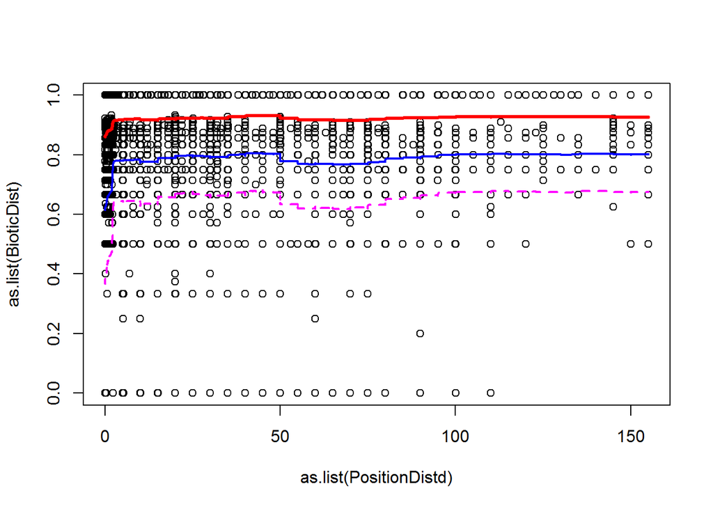

```r
#Just to see what the matrix comparisons look like
bandplot(as.list(PositionDistd), as.list(BioticDist))
```

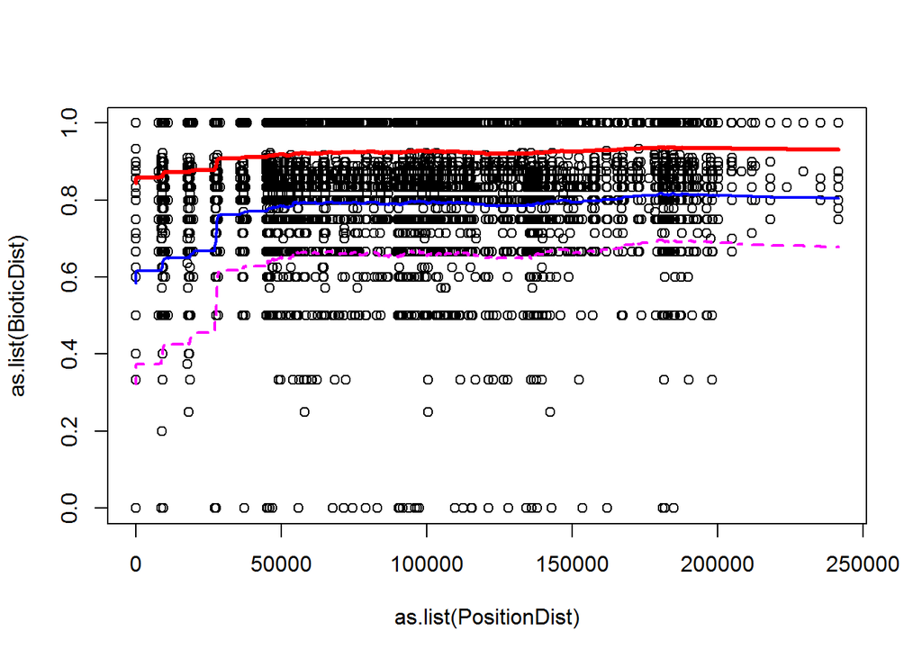

```r
bandplot(as.list(PositionDist), as.list(BioticDist))
```

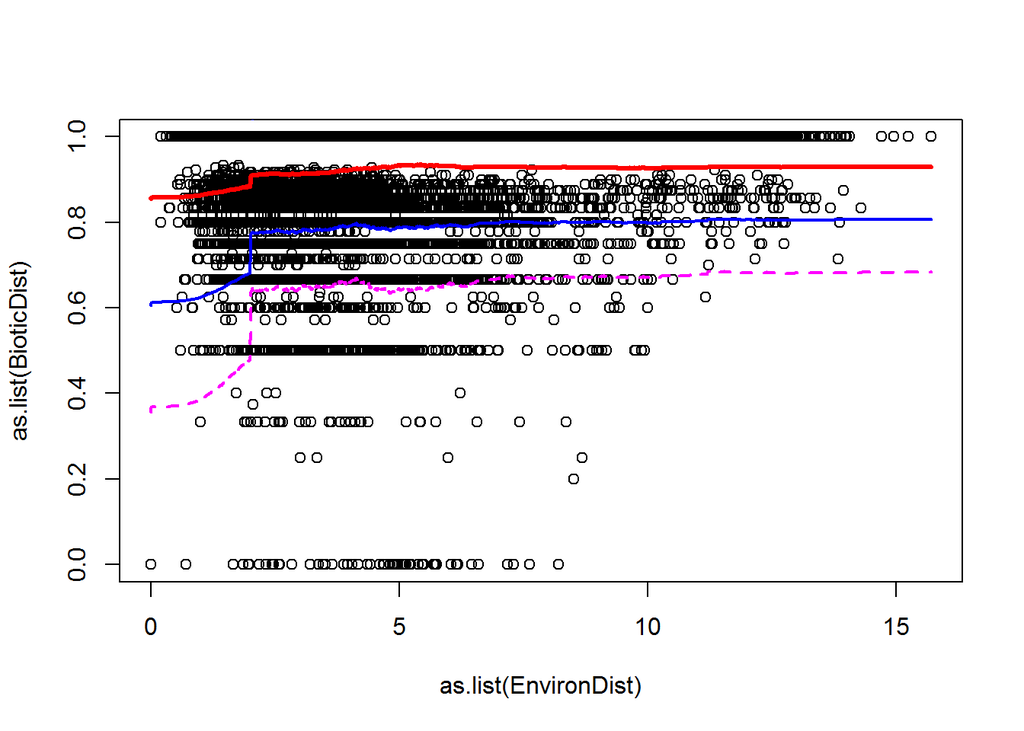

```r
bandplot(as.list(EnvironDist), as.list(BioticDist))
```

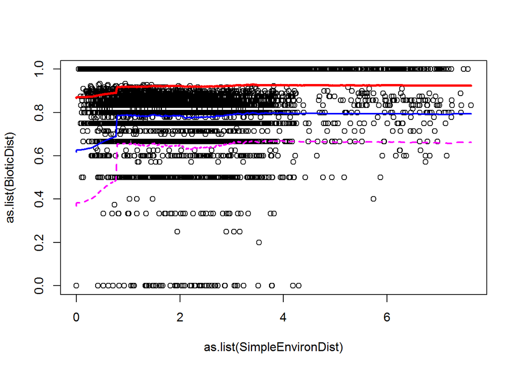

```r
bandplot(as.list(SimpleEnvironDist), as.list(BioticDist))
```

Results: No strong relationships or trends.